# Unsupervised Learning

Kelvin Kilel

1/29/2022

# Specifying the Question

The brand’s Sales and Marketing team would like to understand their customer’s behavior from data that they have collected over the past year. More specifically, they would like to learn the characteristics of customer groups.

i). Perform clustering stating insights drawn from your analysis and visualizations.

ii). Upon implementation, provide comparisons between the approaches learned this week i.e. K-Means clustering vs Hierarchical clustering highlighting the strengths and limitations of each approach in the context of your analysis.

# Defining the Metric of Success

To analyze the different variables and create insights on the customers’ behaviors.

Perform clustering and draw insights from analysis and visualizations.

Provide comparison between K- Means Clustering and Hierachial Clustering.

# Understanding the Context

Kira Plastinina is a Russian brand that is sold through a defunct chain of retail stores in Russia, Ukraine, Kazakhstan, Belarus, China, Philippines, and Armenia. The brand’s Sales and Marketing team would like to understand their customer’s behavior from data that they have collected over the past year.

# Recording the Experimental Design

1. Problem Definition
2. Data Sourcing
3. Check the Data
4. Perform Data Cleaning
5. Perform Exploratory Data Analysis (Univariate, Bivariate & Multivariate)
6. Implement the Solution
7. Challenge the Solution
8. Follow up Questions

# Data Sourcing

```r
# Loading the Required Libraries
# data.table::update.dev.pkg()
library(data.table)
```

```r
# Reading the Dataset
df = read.csv(url("http://bit.ly/EcommerceCustomersDataset"))
```

```r
#Previewing the top dataset
head(df)
```

```
##   Administrative Administrative_Duration Informational Informational_Duration
## 1              0                       0             0                      0
## 2              0                       0             0                      0
## 3              0                      -1             0                     -1
## 4              0                       0             0                      0
## 5              0                       0             0                      0
## 6              0                       0             0                      0
##   ProductRelated ProductRelated_Duration BounceRates ExitRates PageValues
## 1              1                0.000000  0.20000000 0.2000000          0
## 2              2               64.000000  0.00000000 0.1000000          0
## 3              1               -1.000000  0.20000000 0.2000000          0
## 4              2                2.666667  0.05000000 0.1400000          0
## 5             10              627.500000  0.02000000 0.0500000          0
## 6             19              154.216667  0.01578947 0.0245614          0
##   SpecialDay Month OperatingSystems Browser Region TrafficType
## 1          0   Feb                1       1      1           1
## 2          0   Feb                2       2      1           2
## 3          0   Feb                4       1      9           3
## 4          0   Feb                3       2      2           4
## 5          0   Feb                3       3      1           4
## 6          0   Feb                2       2      1           3
##         VisitorType Weekend Revenue
## 1 Returning_Visitor   FALSE   FALSE
## 2 Returning_Visitor   FALSE   FALSE
## 3 Returning_Visitor   FALSE   FALSE
## 4 Returning_Visitor   FALSE   FALSE
## 5 Returning_Visitor    TRUE   FALSE
## 6 Returning_Visitor   FALSE   FALSE
```

```r
# Checking the class types
str(df)
```

```
## 'data.frame':    12330 obs. of  18 variables:
##  $ Administrative         : int  0 0 0 0 0 0 0 1 0 0 ...
##  $ Administrative_Duration: num  0 0 -1 0 0 0 -1 -1 0 0 ...
##  $ Informational          : int  0 0 0 0 0 0 0 0 0 0 ...
##  $ Informational_Duration : num  0 0 -1 0 0 0 -1 -1 0 0 ...
##  $ ProductRelated         : int  1 2 1 2 10 19 1 1 2 3 ...
##  $ ProductRelated_Duration: num  0 64 -1 2.67 627.5 ...
##  $ BounceRates            : num  0.2 0 0.2 0.05 0.02 ...
##  $ ExitRates              : num  0.2 0.1 0.2 0.14 0.05 ...
##  $ PageValues             : num  0 0 0 0 0 0 0 0 0 0 ...
##  $ SpecialDay             : num  0 0 0 0 0 0 0.4 0 0.8 0.4 ...
##  $ Month                  : chr  "Feb" "Feb" "Feb" "Feb" ...
##  $ OperatingSystems       : int  1 2 4 3 3 2 2 1 2 2 ...
##  $ Browser                : int  1 2 1 2 3 2 4 2 2 4 ...
##  $ Region                 : int  1 1 9 2 1 1 3 1 2 1 ...
##  $ TrafficType            : int  1 2 3 4 4 3 3 5 3 2 ...
##  $ VisitorType            : chr  "Returning_Visitor" "Returning_Visitor" "Returning_Visitor" "Returning_Visitor" ...
##  $ Weekend                : logi  FALSE FALSE FALSE FALSE TRUE FALSE ...
##  $ Revenue                : logi  FALSE FALSE FALSE FALSE FALSE FALSE ...
```

```r
#Checking for dimensions

dim(df)
```

```
## [1] 12330    18
```

```r
## There dataset has 12,330 rows and 18 columns.
```

```r
# Checking for summary

summary(df)
```

```
##  Administrative   Administrative_Duration Informational
##  Min.   : 0.000   Min.   :  -1.00         Min.   : 0.000
##  1st Qu.: 0.000   1st Qu.:   0.00         1st Qu.: 0.000
##  Median : 1.000   Median :   8.00         Median : 0.000
##  Mean   : 2.318   Mean   :  80.91         Mean   : 0.504
##  3rd Qu.: 4.000   3rd Qu.:  93.50         3rd Qu.: 0.000
##  Max.   :27.000   Max.   :3398.75         Max.   :24.000
##  NA's   :14       NA's   :14              NA's   :14
##  Informational_Duration ProductRelated   ProductRelated_Duration
##  Min.   :  -1.00        Min.   :  0.00   Min.   :   -1.0
##  1st Qu.:   0.00        1st Qu.:  7.00   1st Qu.:  185.0
##  Median :   0.00        Median : 18.00   Median :  599.8
##  Mean   :  34.51        Mean   : 31.76   Mean   : 1196.0
##  3rd Qu.:   0.00        3rd Qu.: 38.00   3rd Qu.: 1466.5
##  Max.   :2549.38        Max.   :705.00   Max.   :63973.5
##  NA's   :14             NA's   :14       NA's   :14
##   BounceRates         ExitRates         PageValues        SpecialDay
##  Min.   :0.000000   Min.   :0.00000   Min.   :  0.000   Min.   :0.00000
##  1st Qu.:0.000000   1st Qu.:0.01429   1st Qu.:  0.000   1st Qu.:0.00000
##  Median :0.003119   Median :0.02512   Median :  0.000   Median :0.00000
##  Mean   :0.022152   Mean   :0.04300   Mean   :  5.889   Mean   :0.06143
##  3rd Qu.:0.016684   3rd Qu.:0.05000   3rd Qu.:  0.000   3rd Qu.:0.00000
##  Max.   :0.200000   Max.   :0.20000   Max.   :361.764   Max.   :1.00000
##  NA's   :14         NA's   :14
##     Month           OperatingSystems    Browser           Region
##  Length:12330       Min.   :1.000    Min.   : 1.000   Min.   :1.000
##  Class :character   1st Qu.:2.000    1st Qu.: 2.000   1st Qu.:1.000
##  Mode  :character   Median :2.000    Median : 2.000   Median :3.000
##                     Mean   :2.124    Mean   : 2.357   Mean   :3.147
##                     3rd Qu.:3.000    3rd Qu.: 2.000   3rd Qu.:4.000
##                     Max.   :8.000    Max.   :13.000   Max.   :9.000
##
##   TrafficType    VisitorType         Weekend         Revenue
##  Min.   : 1.00   Length:12330       Mode :logical   Mode :logical
##  1st Qu.: 2.00   Class :character   FALSE:9462      FALSE:10422
##  Median : 2.00   Mode  :character   TRUE :2868      TRUE :1908
##  Mean   : 4.07
##  3rd Qu.: 4.00
##  Max.   :20.00
##
```

# Data Cleaning

```r
# Changing the loaded dataset to dataframe

customer_df <- as.data.frame(df)
```

```r
#Making the column names uniform

colnames(customer_df) = tolower(colnames(df))
```

```r
# Checking for duplicates
duplicates <- customer_df[duplicated(customer_df),]
dim(duplicates)
```

```
## [1] 119  18
```

```r
# Dropping the duplicates

df2 <- customer_df[!duplicated(customer_df),]

dim(df2)
```

```
## [1] 12211    18
```

```r
# Checking for missing values

colSums(is.na(df2))
```

```
##          administrative administrative_duration           informational
##                      12                      12                      12
##  informational_duration          productrelated productrelated_duration
##                      12                      12                      12
##             bouncerates               exitrates              pagevalues
##                      12                      12                       0
##              specialday                   month        operatingsystems
##                       0                       0                       0
##                 browser                  region             traffictype
##                       0                       0                       0
##             visitortype                 weekend                 revenue
##                       0                       0                       0
```

```r
# Dropping missing values

df3 = na.omit(df2)

colSums(is.na(df3))
```

```
##          administrative administrative_duration           informational
##                       0                       0                       0
##  informational_duration          productrelated productrelated_duration
##                       0                       0                       0
##             bouncerates               exitrates              pagevalues
##                       0                       0                       0
##              specialday                   month        operatingsystems
##                       0                       0                       0
##                 browser                  region             traffictype
##                       0                       0                       0
##             visitortype                 weekend                 revenue
##                       0                       0                       0
```

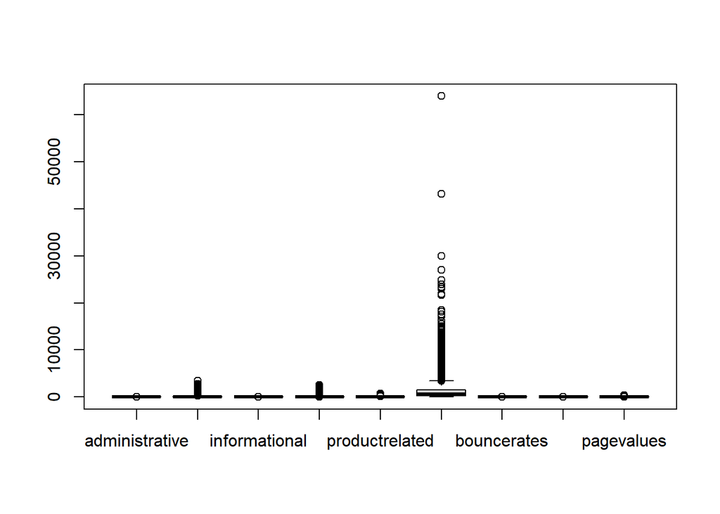

```r
# Checking for Outliers

num_cols <- subset(df3, select = -c(specialday, month, operatingsystems,browser, region, traffictype, visitortype,weekend,revenue))

boxplot(num_cols)
```

```r
### All numerical columns have outliers.We will leave the outliers since the dataset is computer generated.
```

# Univariate Analysis

```r
# Loading required libraries
library(ggplot2)
## install.packages("psych")
library(psych)
```

i.) Central Tendencies

```r
describe(num_cols)
```

```
##                         vars     n    mean      sd median trimmed    mad min
## administrative             1 12199    2.34    3.33   1.00    1.66   1.48   0
## administrative_duration    2 12199   81.68  177.53   9.00   42.87  13.34  -1
## informational              3 12199    0.51    1.28   0.00    0.18   0.00   0
## informational_duration     4 12199   34.84  141.46   0.00    3.73   0.00  -1
## productrelated             5 12199   32.06   44.60  18.00   23.06  19.27   0
## productrelated_duration    6 12199 1207.51 1919.93 609.54  832.36 745.12  -1
## bouncerates                7 12199    0.02    0.05   0.00    0.01   0.00   0
## exitrates                  8 12199    0.04    0.05   0.03    0.03   0.02   0
## pagevalues                 9 12199    5.95   18.66   0.00    1.33   0.00   0
##                              max    range skew kurtosis    se
## administrative             27.00    27.00 1.95     4.63  0.03
## administrative_duration  3398.75  3399.75 5.59    50.09  1.61
## informational              24.00    24.00 4.01    26.64  0.01
## informational_duration   2549.38  2550.38 7.54    75.45  1.28
## productrelated            705.00   705.00 4.33    31.04  0.40
## productrelated_duration 63973.52 63974.52 7.25   136.57 17.38
## bouncerates                 0.20     0.20 3.15     9.25  0.00
## exitrates                   0.20     0.20 2.23     4.62  0.00
## pagevalues                361.76   361.76 6.35    64.93  0.17
```

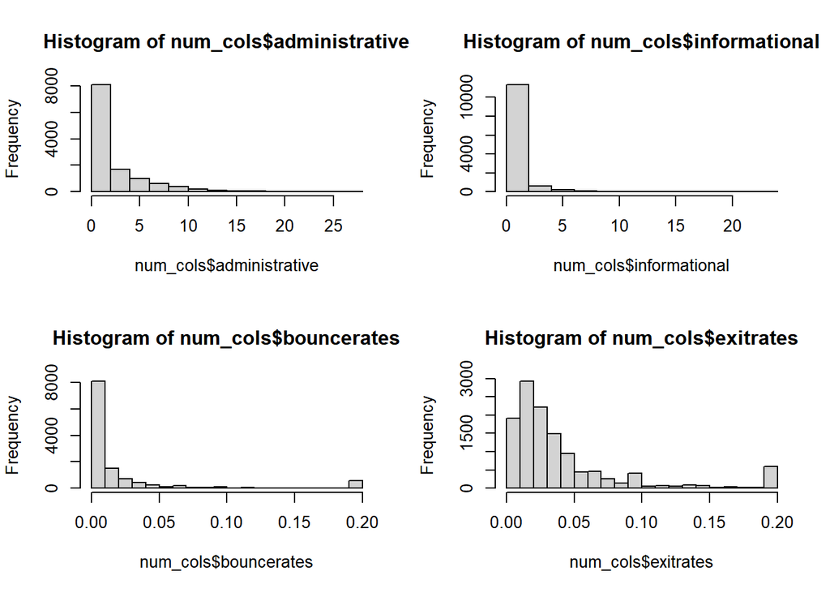

```r
par(mfrow = c(2, 2))
hist(num_cols$administrative)
hist(num_cols$informational)
hist(num_cols$bouncerates)
hist(num_cols$exitrates)
```

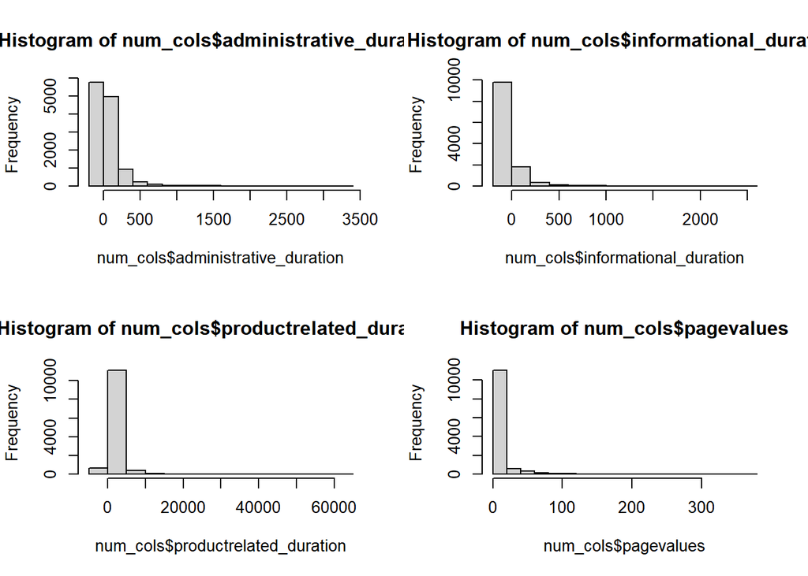

```r
par(mfrow = c(2, 2))
hist(num_cols$administrative_duration)
hist(num_cols$informational_duration)
hist(num_cols$productrelated_duration)
hist(num_cols$pagevalues)
```

## Categorical Analysis

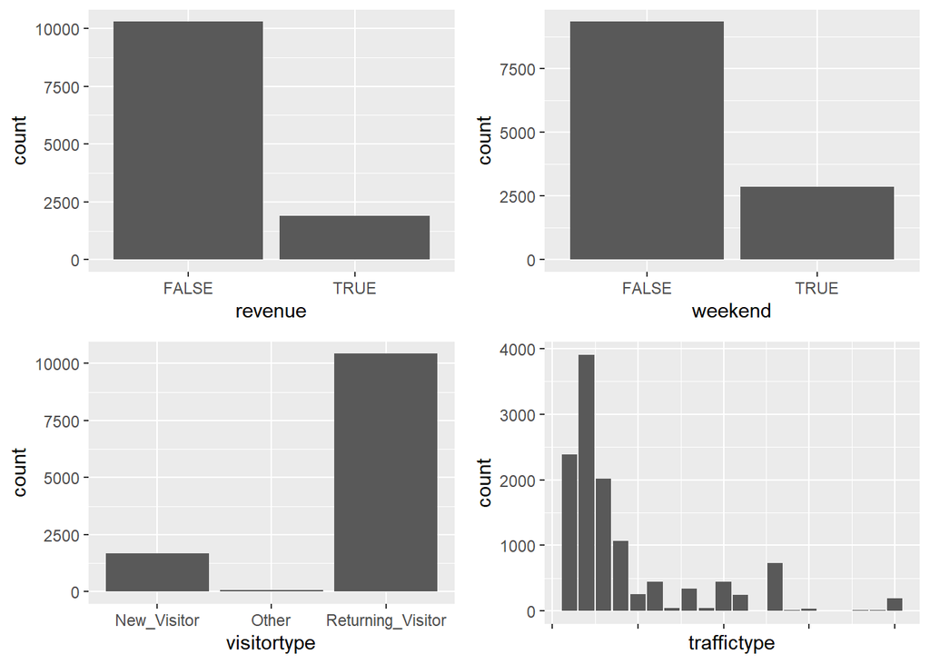

```r
# install.packages("ggpubr")
library(ggpubr)

r <- ggplot(data = df3) +
  geom_bar(mapping = aes(x = revenue))
#Was traffic high on weekends or not?
w <- ggplot(data = df3) +
  geom_bar(mapping = aes(x = weekend))
#What group of visitors frequented the website?
v <-ggplot(data = df3) +
  geom_bar(mapping = aes(x = visitortype))
#What traffic type was mostly used?
t <- ggplot(data = df3) +
  geom_bar(mapping = aes(x = traffictype))
ggarrange(r, w, v, t + rremove("x.text"),
          ncol = 2, nrow = 2)
```

#### 1. Most of the traffic in the website doesn’t generate any revenue.

#### 2. There is more traffic on weekdays than weekends.

#### 3. Most of the people visiting the website are returning visitors. Only a small percentage of the visitors are new.

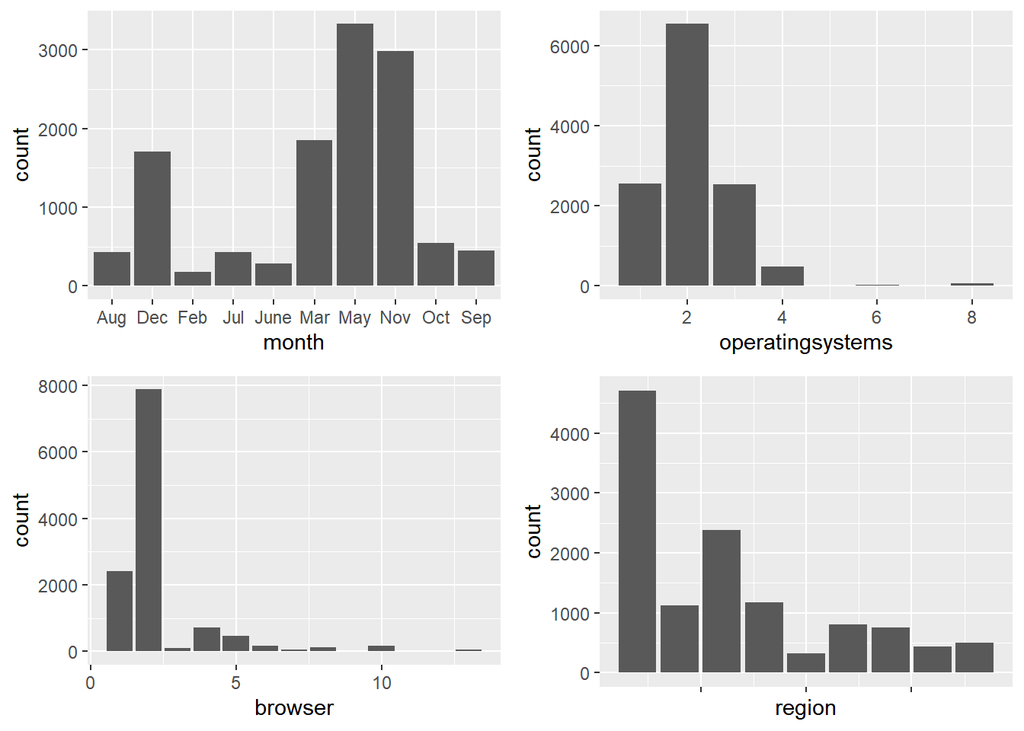

```r
#Which months had the highest traffic
m <- ggplot(data = df3) +
  geom_bar(mapping = aes(x = month))

#Distribution of operating systems on traffic
o <- ggplot(data = df3) +
  geom_bar(mapping = aes(x = operatingsystems))

#Browser distribution
b <-ggplot(data = df3) +
  geom_bar(mapping = aes(x = browser))

#Which regions trafficked the website the most?
r <- ggplot(data = df3) +
  geom_bar(mapping = aes(x = region))

ggarrange(m, o, b, r + rremove("x.text"),
          ncol = 2, nrow = 2)
```

#### There is a lot of traffic in the website in the months of March, May, November and Dec

#### Region 1 had more traffic compared to the other regions. Region 3 also had significantly high traffic.

# Bivariate Analysis

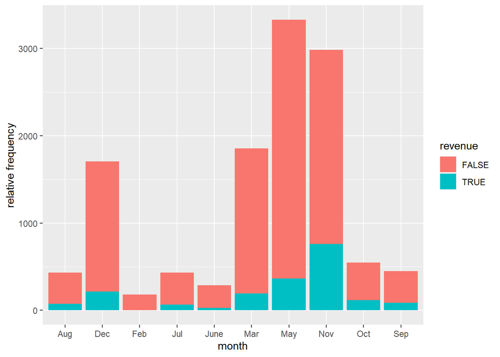

```r
# Revenue generated monthly
df3 %>%
  ggplot() +
  aes(x = month, revenue = ..count../nrow(df3), fill = revenue) +
  geom_bar() +
  ylab("relative frequency")
```

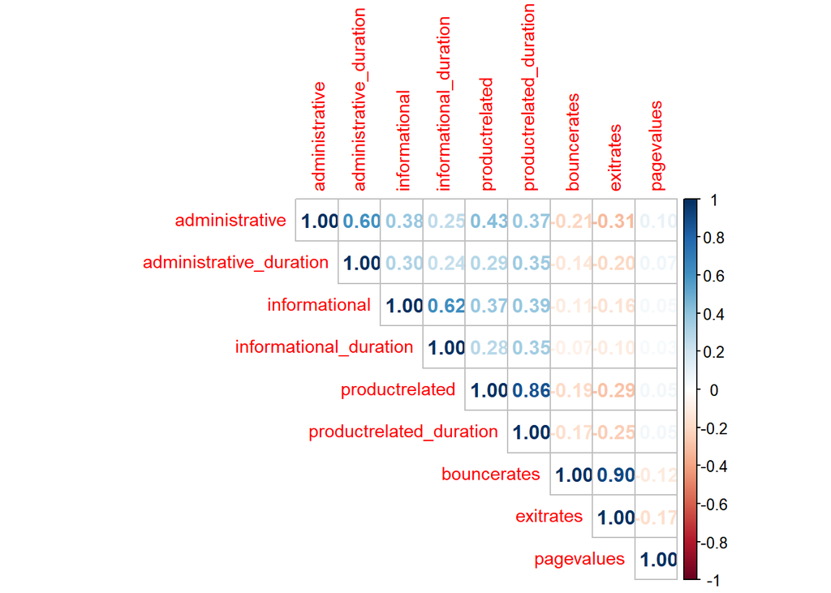

```r
library(corrplot)
corrplot(cor(num_cols), type= 'upper', method = 'number', tl.cex = 0.9)
```

#### There is a strong positive relationship between product related and product related duartion.

#### There is also a strong positive relationship between exit rates and bounce rates.

# Implementing the Solution

## Feature Engineering

```r
#Removing the weekend column
model <- subset(df3, select = -c(weekend))
#Separating features from target
new_model <- model[, c(1,2,3,4,5,6,7,8,9,10)]
class_model <- model[, "revenue"]
head(new_model)
```

```
##   administrative administrative_duration informational informational_duration
## 1              0                       0             0                      0
## 2              0                       0             0                      0
## 3              0                      -1             0                     -1
## 4              0                       0             0                      0
## 5              0                       0             0                      0
## 6              0                       0             0                      0
##   productrelated productrelated_duration bouncerates exitrates pagevalues
## 1              1                0.000000  0.20000000 0.2000000          0
## 2              2               64.000000  0.00000000 0.1000000          0
## 3              1               -1.000000  0.20000000 0.2000000          0
## 4              2                2.666667  0.05000000 0.1400000          0
## 5             10              627.500000  0.02000000 0.0500000          0
## 6             19              154.216667  0.01578947 0.0245614          0
##   specialday
## 1          0
## 2          0
## 3          0
## 4          0
## 5          0
## 6          0
```

```r
normalize <- function(x) {
  return ((x - min(x)) / (max(x) - min(x)))
}

cust_norm <- as.data.frame(lapply(new_model[,1:10], normalize))

summary(cust_norm)
```

```
##  administrative    administrative_duration informational
##  Min.   :0.00000   Min.   :0.0000000       Min.   :0.0000
##  1st Qu.:0.00000   1st Qu.:0.0002941       1st Qu.:0.0000
##  Median :0.03704   Median :0.0029414       Median :0.0000
##  Mean   :0.08667   Mean   :0.0243201       Mean   :0.0212
##  3rd Qu.:0.14815   3rd Qu.:0.0281638       3rd Qu.:0.0000
##  Max.   :1.00000   Max.   :1.0000000       Max.   :1.0000
##  informational_duration productrelated    productrelated_duration
##  Min.   :0.0000000      Min.   :0.00000   Min.   :0.000000
##  1st Qu.:0.0003921      1st Qu.:0.01135   1st Qu.:0.003042
##  Median :0.0003921      Median :0.02553   Median :0.009543
##  Mean   :0.0140518      Mean   :0.04547   Mean   :0.018891
##  3rd Qu.:0.0003921      3rd Qu.:0.05390   3rd Qu.:0.023112
##  Max.   :1.0000000      Max.   :1.00000   Max.   :1.000000
##   bouncerates        exitrates         pagevalues        specialday
##  Min.   :0.00000   Min.   :0.00000   Min.   :0.00000   Min.   :0.00000
##  1st Qu.:0.00000   1st Qu.:0.07111   1st Qu.:0.00000   1st Qu.:0.00000
##  Median :0.01465   Median :0.12500   Median :0.00000   Median :0.00000
##  Mean   :0.10223   Mean   :0.20748   Mean   :0.01645   Mean   :0.06197
##  3rd Qu.:0.08333   3rd Qu.:0.24242   3rd Qu.:0.00000   3rd Qu.:0.00000
##  Max.   :1.00000   Max.   :1.00000   Max.   :1.00000   Max.   :1.00000
```